# An Analysis on the Correlation Between Welfare, Economic Strength, and Data Maturity on the East Asia and Pacific Region

Brian Godwin Lim, Terence Brian Tsai

# Abstract

East Asia and the Pacific is an enormous region that stretches from Mongolia at the North, down to the lesser-known country of Tonga. It is the most diversified region in the world both culturally and economically. Various economic powerhouses such as China, Hong Kong, Singapore, Japan, and Australia are located here. On the other side of the economic spectrum, several developing countries such as the Philippines, Palau, Papua New Guinea, and Indonesia, among others, can also be found here.

Over the past three decades, this region has experienced very rapid growth which brought about the emergence of previously poor countries as today’s economic powerhouses. This includes the emergence of China, Hong Kong, and Singapore as some of the world’s biggest economies, joining Australia, and Japan, among others, as the first world countries in this region. On the other hand, several developing countries can also be found here. These include countries such as the Philippines, Palau, Papua New Guinea, and Indonesia. These countries are expected to experience hypergrowth in the next few years driven by a new wave of economic growth centered around the Huanan (South China) economic sphere, a quickening of intra-regional trade, and a rise in intra-regional interdependence all of which are expected to push the economic output of countries in this region even higher. (A Long-Term Perspective on Environment and Development in the Asia-Pacific Region, n.d.). It is projected that by 2025, the GDP of the region will be equal to that of the output of both North and South America combined. The region has been the world’s center of growth and is seen to continue as the world’s growth engine for years to come.

However, in March 2020, the world experienced an economic shock it has never experienced before when COVID-19 was officially declared as a pandemic. Lockdowns ensued, international trade was disrupted, the tourism industry was put to a halt, and the health crisis also turned into an extremely big economic crisis. The pandemic caused a significant decrease in income, high unemployment rates, and a decrease in the overall welfare of people in the region. In the Asia Pacific region, where international trade was a significant driver of the economy, the ripple effects of the pandemic hit the nations in the region especially hard. Only a few countries have been able to recover from the pandemic, and as such, most of the countries in the region still suffer from the spike in income inequality due to the economic crisis. As such, it is imperative that the overall effect of the economic strength on the welfare of the people be studied.

In this project we will view the relationship between 1.) overall welfare and inclusivity of the population in the region, 2.) a robust and improving economy backed by international trade, and 3.) the level of maturity in data use with respect to policy-making. Principal component analysis (PCA) was conducted using the information on 9 World Development Indicators (WDI) on different factors concerning the economic capabilities of the countries, using various variables such as merchandise trade and GDP per capita, the overall welfare of the population based on different factors such as access to healthcare, labor security, and gender equality, and finally the data use of the country using the statistical performance indicator pillar 1. The variables were reduced to three principal components, which were interpreted as 1.) Overall Welfare of the Population, 2.) Economic Strength of the Country, and 3.) Data Maturity. Finally, we were able to conclude that the Overall Welfare of the Population and Economic Strength of the Country has a clear linear trend. This confirms that the hypergrowth of the economies in this regions in the recent years indeed translated to the increase in the overall welfare of the population.

# Research Question

With the rapid growth of countries in the East Asia and Pacific Region, there comes a question of how this economic growth translates to the increase in the welfare of the entire population. Moreover, the question of whether this growth mostly benefits the rich people or if the growth resonates with the entire society must still be examined. As such, this analysis aims to address the question of:

1. Whether the economic strength of this region brought about by the recent hypergrowth has translated to good welfare of the overall population.
2. Whether the welfare of the overall population can be correlated with a data-driven policy-making by political leaders.
3. Whether this economic strength is correlated to a strong data-centric approach to governance.

# Motivation on choice of dataset

Given the goal of this research, the 9 WDI indicators were chosen on the basis of either the representation of the economic development of a country, variables that represent the welfare of the society, or the representation of data maturity of a country. The indicators were gathered for the year of 2019, right before the COVID-19 pandemic hit the world.

The following are the dataset chosen on the motivation behind the choice of this dataset.

1. **GDP per Capita (constant 2015 US$)**  
   GDP per Capita pertains to the gross domestic product divided by the population of a country. It is the monetary value of the economic output of the country and is a good representation of both a country’s economic robustness, and the standard of living of the people in the country. It describes how much each citizen, on average, benefit from their country’s economy.
2. **School Enrollment, Secondary (% gross)**  
   Gross enrollment ratio indicates the capacity of the secondary level of education system to cater to their students. Education, which is a basic human right, is extremely important for human development and welfare and as such, this variable was selected to represent this aspect of the population’s welfare.
3. **Access to Electricity, Rural (% of rural population)**  
   This variable represents the percentage of the rural population with access to electricity. This was chosen as an indicator as access to electricity is necessary for the prosperity of a community. Access to electricity is extremely important as in today’s day and age. It is indispensable in some of the basic activities which need lighting, refrigeration, and running of household appliances. This variable was chosen because of its relevance to human development and welfare.
4. **Women Business and the Law Index Score (scale 1-100)**  
   Women Business and the Law Index Score measures how a country’ laws and regulations influences women’s economic opportunities. It tracks how a country progresses in terms of the legal equality between both sexes. It measures areas ranging from job opportunities, to mobility, to managing assets. This variable was chosen because of it highlights the welfare of women, which might not be properly represented in other indicators.
5. **Prevalance of Undernourishment (% of population)**  
   East Asia and Pacific is considered to be the epicenter of malnutrition. As such, we considered it important to include the prevalence of undernourishment as a variable. Good nutrition is a necessity for survival and development. Having good nutrition prepares children to excel in school and grow up to be adults who are able to give their children better lives. Well-nourished men and women are able to work better and provide better for their families. Moreover, women are also able to avoid pregnancy complications leading to a better life for their family. As such, we consider nourishment as a cornerstone for human development and the prevalence of undernourishment as a factor that harms the welfare of the population.
6. **Secure Internet Servers (per 1 million people)**  
   This variable pertains to the number of secure internet servers per 1 million people in the country. In the digital world of today, the quality of infrastructure, especially those concerning internet connectivity, is essential for both improving the GDP as well as the quality of life of the population. The quality of infrastructure, especially telecommunications infrastructure in the modern age, drives investment decisions which is what ultimately improves the economy.
7. **Merchandise Trade (% of GDP)**  
   This variable refers to the total amount of merchandise imports and imports as a share of the total GDP. It is a good measure of interdependence of the economies. Given that the countries in this region have benefited vastly from interregional trade, it is appropriate to include this as an indicator for the economic strength of a country.
8. **Statistical Performance Indicators (SPI) Pillar 1 data use score (scale 0-100)**  
   SPI pillar 1 refers to legislation and governance covering the existence of laws and a functioning institutional framework for the statistical system; A higher score represents a better capability of the existence of laws and framework. In today’s information age, the existence of institutional frameworks and laws that govern data use, data services, data products, data sources, and data infrastructure is essential for both the welfare and development of a society.
9. **Vulnerable Employment, total (% of total employment) (modeled ILO estimate)**  
   Vulnerable Employment refers to the % of the total employment that comes in the form of self-employment without employees, referred to as own-account workers, and those who are working family members who are unpaid. This group usually lacks social protection and thus, are more vulnerable to shock and are the most likely to fall into poverty. Thus, this variable was included to represent job and individual economic security of each person in the population, which is essential for their welfare and development.

```r
data_raw = import("WDIEXCEL.xlsx", which = 1)
country = import("WDIEXCEL.xlsx", which = 2)
series = import('WDIEXCEL.xlsx', which = 3)

indicators = c(
  "GDP per capita (constant 2015 US$)", # Economic Policy and Debt
  "School enrollment, secondary (% gross)", # Education
  "Access to electricity, rural (% of rural population)", # Environment
  "Women Business and the Law Index Score (scale 1-100)", # Gender
  "Prevalence of undernourishment (% of population)", # Health
  "Secure Internet servers (per 1 million people)", # Infrastructure
  "Merchandise trade (% of GDP)", # Private Sector and Trade
  "Statistical performance indicators (SPI): Pillar 1 data use score (scale 0-100)", # Public Sector
  "Vulnerable employment, total (% of total employment) (modeled ILO estimate)" # Social Protection and Labor
)

df = data_raw %>%
  left_join(
    country,
    by = "Country Code"
  ) %>%
  filter(
    Region == "East Asia & Pacific",
    `Indicator Name` %in% indicators
  ) %>%
  select(`Country Name`, `Indicator Name`, `2019`) %>%
  spread(
    key = "Indicator Name", value = "2019"
  )
```

# Details on Transformation of Data and Missing Values

The dataset was chosen from the ones that had as little missing values as possible. However, it is unavoidable that some countries lack the data in some categories. For the missing values, the data was imputed from the values of the other countries for the same variable using the `missMDA::imputePCA()` function (PCA - Principal Component Analysis Essentials, 2017).

```r
for (idx in 1:dim(df)[2]){
  split = str_split(colnames(df)[idx], " ")[[1]][1]
  colnames(df)[idx] = split
}

rownames(df) = df$`Country`
df = df %>% select(-`Country`)

df = imputePCA(df, method = "EM",
               ncp = estim_ncpPCA(df)$ncp)$completeObs

df %>% write.csv("Final_Data.csv")
# df = import("Final_Data.csv")
# rownames(df) = df$`V1`
# df = df %>% select(-`V1`)
```

## Data Exploration

Before performing PCA, we first take a look at the final dataset we will be using in this project.

```r
df
```

```
##                              Access       GDP Merchandise Prevalence    School
## American Samoa             73.01211 11331.417   168.02508  21.577007  43.66422
## Australia                 100.00000 58923.208    35.26999   2.500000 140.64604
## Brunei Darussalam         100.00000 30646.109    90.14492   2.500000  92.09572
## Cambodia                   90.90677  1439.162   129.58579   6.200000  84.45748
## China                     100.00000 10228.293    32.05786   2.500000  97.81909
## Fiji                      100.00000  5869.014    68.53763   5.600000  95.18632
## French Polynesia          100.00000 21411.488    55.34124   3.800000 103.52281
## Guam                      100.00000 35407.682    17.14467   1.904928 109.61339
## Hong Kong SAR, China      100.00000 44189.693   306.52088   2.500000 107.74028
## Indonesia                  97.52717  3877.383    30.28877   6.500000  89.80276
## Japan                     100.00000 36362.357    27.70599   2.500000 112.69265
## Kiribati                  100.00000  1614.528    73.98000   4.100000  84.90624
## Korea, Dem. People's Rep.  61.47065 58710.201   436.09983  42.400000  11.85796
## Korea, Rep.               100.00000 31610.919    63.49372   2.500000  95.86535
## Lao PDR                   100.00000  2572.828    66.19560   5.300000  65.76873
## Macao SAR, China          100.00000 79677.664    23.12265   4.300000 101.03669
## Malaysia                  100.00000 11391.692   121.52883   3.200000  83.74816
## Marshall Islands          100.00000  3595.208    51.36510  13.154045  63.94497
## Micronesia, Fed. Sts.      78.07066  2921.882    59.79504  16.304666  56.23521
## Mongolia                   97.21927  4378.528    98.21587   4.300000  91.50336
## Myanmar                    57.50791  1362.725    46.00078   7.600000  67.88447
## Nauru                     100.00000  8349.919    46.52208   7.848260  96.70418
## New Caledonia             100.00000 24411.848    71.08076   6.900000 101.86838
## New Zealand               100.00000 40315.471    38.46099   2.500000 123.14418
## Northern Mariana Islands  100.00000 18141.882    50.50761   6.092257  93.38857
## Palau                     100.00000 15213.716    65.58479  12.210460  72.06162
## Papua New Guinea           60.44654  2853.905    61.75413  24.600000  48.32253
## Philippines                93.54533  3664.791    49.97064   9.400000  89.76527
## Samoa                      99.02372  4430.006    51.62803   4.600000 100.61086
## Singapore                 100.00000 61173.905   200.33559  10.982638 104.71496
## Solomon Islands            68.22146  2289.587    66.93348  16.500000  58.36984
## Thailand                   99.90000  6617.543    88.65716   8.200000 115.15266
## Timor-Leste                92.34816  1435.728    36.91911  22.600000  86.53527
## Tonga                      97.91920  4652.589    50.35620   7.222273  94.09309
## Tuvalu                    100.00000  3674.354    69.80956  13.277959  66.04343
## Vanuatu                    54.42644  2882.402    42.02774   9.300000  58.36756
## Vietnam                    99.05321  2604.224   197.63994   6.700000  89.75198
##                                  Secure Statistical Vulnerable    Women
## American Samoa               343.505930        30.0   81.71695 52.65717
```

[output cut: 21 more lines]

```
## New Caledonia               4898.636196        70.0   13.71000 79.68496
## New Zealand                20120.498865       100.0   12.29000 94.37500
## Northern Mariana Islands    1363.326517        60.0   37.49011 75.43704
## Palau                        722.182101        30.0   57.99879 58.75000
## Papua New Guinea              56.744901        60.0   74.00000 60.00000
## Philippines                  111.314984       100.0   33.21000 78.75000
## Samoa                        471.858463        90.0   29.18000 80.00000
## Singapore                 122481.379641       100.0    9.20000 82.50000
## Solomon Islands               56.731575        60.0   62.02000 56.87500
## Thailand                    1403.808752       100.0   47.74000 78.12500
## Timor-Leste                   37.892848        50.0   68.00000 83.12500
## Tonga                        229.671665        90.0   46.85000 58.75000
## Tuvalu                        85.800086        10.0   64.74178 62.77903
## Vanuatu                      350.137721        60.0   67.85000 58.12500
## Vietnam                     2596.988654       100.0   52.29000 78.75000
```

```r
df %>%
  summary()
```

```
##      Access            GDP         Merchandise       Prevalence
##  Min.   : 54.43   Min.   : 1363   Min.   : 17.14   Min.   : 1.905
##  1st Qu.: 93.55   1st Qu.: 2922   1st Qu.: 46.00   1st Qu.: 3.800
##  Median :100.00   Median : 6618   Median : 61.75   Median : 6.500
##  Mean   : 92.45   Mean   :17844   Mean   : 86.18   Mean   : 8.924
##  3rd Qu.:100.00   3rd Qu.:30646   3rd Qu.: 88.66   3rd Qu.:10.983
##  Max.   :100.00   Max.   :79678   Max.   :436.10   Max.   :42.400
##      School           Secure          Statistical       Vulnerable
##  Min.   : 11.86   Min.   : -9204.0   Min.   : 10.00   Min.   : 3.30
##  1st Qu.: 67.88   1st Qu.:   159.3   1st Qu.: 60.00   1st Qu.:13.71
##  Median : 91.50   Median :   735.0   Median : 80.00   Median :46.95
##  Mean   : 86.46   Mean   : 11817.5   Mean   : 69.82   Mean   :41.68
##  3rd Qu.:101.04   3rd Qu.:  4543.8   3rd Qu.:100.00   3rd Qu.:62.42
##  Max.   :140.65   Max.   :141838.3   Max.   :100.00   Max.   :85.76
##      Women
##  Min.   :41.19
##  1st Qu.:58.75
##  Median :78.12
##  Mean   :72.48
##  3rd Qu.:82.50
##  Max.   :96.88
```

```r
data.frame(Mean = round(apply(df, 2, mean),2),
           Variance = round(apply(df, 2, var),2))
```

```
##                 Mean      Variance
## Access         92.45        201.21
## GDP         17844.16  433722350.19
## Merchandise    86.18       6896.55
## Prevalence      8.92         67.23
## School         86.46        608.69
## Secure      11817.51 1001344935.68
## Statistical    69.82        899.40
## Vulnerable     41.68        626.06
## Women          72.48        186.58
```

# Performing PCA

To perform PCA, we use the `prcomp()` function. This produces the principal component loading vectors, standard deviations of each principal component, and the principal components, among others. We also note that there are 9 principal components. This is computed as $M = \min(n-1, p) = \min(37-1, 9) = 9$, where $n$ is the number of observations (countries) and $p$ is the number of indicators. Moreover, before performing the PCA, the dataset was demeaned. Moreover, to avoid one variable dominating the variance due to its absolute size, the dataset was also normalized.

```r
pca = prcomp(df, center = TRUE, scale = TRUE)
pca
```

```
## Standard deviations (1, .., p=9):
## [1] 2.0916029 1.5305690 0.8800190 0.7339146 0.6802523 0.4577521 0.3626855
## [8] 0.3237601 0.2466789
##
## Rotation (n x k) = (9 x 9):
##                     PC1          PC2         PC3         PC4         PC5
## Access       0.36326308 -0.001695393 -0.54011552  0.45193661 -0.24754334
## GDP          0.15406778  0.538530312 -0.12251089 -0.55398023  0.03035232
## Merchandise -0.20700997  0.492761030  0.01496704  0.56704642 -0.16160357
## Prevalence  -0.41959073  0.175974863 -0.07972644 -0.06080939  0.32708944
## School       0.45800252  0.028228387 -0.03579663  0.01517881  0.06873851
## Secure      -0.09365475  0.614027507  0.03129740  0.10416776  0.04893032
## Statistical  0.30490852  0.077533041  0.82061391  0.21156298 -0.02554930
## Vulnerable  -0.41089398 -0.219942859  0.01621858  0.27891727  0.34831237
## Women        0.38085819  0.063156870 -0.10370552  0.17316098  0.82195157
##                     PC6         PC7         PC8         PC9
## Access       0.48036671 -0.26755495  0.05256692  0.07541066
## GDP          0.06658405 -0.48445967  0.02934385 -0.35132360
## Merchandise -0.44678760 -0.12831597 -0.34081456 -0.18496856
## Prevalence   0.54357231  0.09186436 -0.58720118  0.16498405
## School       0.08883141  0.59671028 -0.26734251 -0.58972356
## Secure       0.19443379  0.45102062  0.56751278  0.19151900
## Statistical  0.34757359 -0.24115778 -0.05122778  0.02473502
## Vulnerable   0.19714426 -0.18484519  0.37301775 -0.60929142
## Women       -0.25368405 -0.13038999  0.01032300  0.23054413
```

```r
pca$scale
```

```
##       Access          GDP  Merchandise   Prevalence       School       Secure
##    14.184988 20826.001781    83.045441     8.199594    24.671703 31644.034757
##  Statistical   Vulnerable        Women
##    29.989990    25.021156    13.659472
```

```r
pca$center
```

```
##       Access          GDP  Merchandise   Prevalence       School       Secure
##    92.448611 17844.158176    86.178596     8.923635    86.456385 11817.506528
##  Statistical   Vulnerable        Women
##    69.821622    41.676785    72.481551
```

```r
pca$x
```

```
##                                   PC1         PC2         PC3         PC4
## American Samoa            -3.77303148 -0.22706214 -0.19232575 -0.13098169
## Australia                  3.38230958  1.63049309  0.09053613 -0.86097503
## Brunei Darussalam          1.06341327  0.50072808  0.64084330 -0.45254938
## Cambodia                  -0.14684044 -0.48766906  0.17006563  0.75620547
## China                      1.05592054 -0.81682706  0.13076503  0.23703682
## Fiji                       0.81220988 -0.64294890  0.01402836  0.58882221
## French Polynesia           1.51749697 -0.11606792 -0.64700473 -0.35656901
## Guam                       2.04815199  0.01935031 -0.75019544 -0.96377096
## Hong Kong SAR, China       1.58329535  3.24013524 -0.19606961  1.15082142
## Indonesia                  0.35503672 -0.95546102  0.77897762  0.32177482
## Japan                      2.28817136  0.54651183  0.08332538 -0.67645659
## Kiribati                  -0.07668212 -0.98163640 -1.56363042  0.38196372
## Korea, Dem. People's Rep. -6.94892081  5.63180001 -0.18357940  0.19239880
## Korea, Rep.                1.90642124  0.28827525  0.38497800 -0.13322398
## Lao PDR                    0.07241391 -1.00660426  0.30679942  1.18980834
## Macao SAR, China           2.46308126  1.42145332 -0.49936140 -1.99469404
## Malaysia                   0.08560044 -0.10317493  0.24894183  0.26503332
## Marshall Islands          -1.70559163 -1.13494070 -1.47340489  0.03845506
## Micronesia, Fed. Sts.     -2.60671388 -1.10005560 -0.68458702 -0.44876288
## Mongolia                   0.84958839 -0.49081508  0.68058446  0.99700833
## Myanmar                   -1.57535130 -1.10694657  2.39174175 -0.71956880
## Nauru                     -0.15082512 -1.10489424 -1.60915621 -0.12098939
## New Caledonia              1.35167088  0.19889506 -0.40635214 -0.25466816
## New Zealand                2.86362566  0.79982997  0.22961978 -0.42258491
## Northern Mariana Islands   0.64032304 -0.43547582 -0.58247955 -0.09853772
## Palau                     -1.23309230 -0.66225984 -1.27261884 -0.17286271
## Papua New Guinea          -3.32352922 -0.83136208  1.04054677 -0.83325305
## Philippines                0.70578398 -0.61334506  0.78680526  0.32282871
## Samoa                      1.29286801 -0.65263633  0.31956426  0.43216861
## Singapore                  1.25492086  4.41915446  0.26974716  0.20560236
## Solomon Islands           -2.43089386 -0.88763486  0.82889809 -0.64207356
## Thailand                   1.06676319 -0.41043822  0.52471823  0.89372249
## Timor-Leste               -1.00172841 -0.88496494 -0.65939460  0.24529333
## Tonga                      0.13225932 -0.86375149  0.51659043  0.28570480
## Tuvalu                    -1.69518769 -1.02425687 -1.77973004  0.13437491
## Vanuatu                   -2.41105931 -1.21273745  1.41077830 -1.13221938
## Vietnam                    0.28812175  0.05734019  0.65103486  1.77571771
##                                    PC5         PC6          PC7          PC8
## American Samoa            -0.063394620 -0.28297587 -0.451446090 -0.415369890
```

[output cut: 59 more lines]

```
## New Caledonia              0.314742954
## New Zealand               -0.078585514
## Northern Mariana Islands  -0.027635723
## Palau                     -0.188616801
## Papua New Guinea           0.287031809
## Philippines                0.522183626
## Samoa                      0.292053086
## Singapore                  0.314524436
## Solomon Islands            0.162191369
## Thailand                  -0.567534649
## Timor-Leste                0.110280427
## Tonga                     -0.296590532
## Tuvalu                     0.045423075
## Vanuatu                   -0.129583581
## Vietnam                   -0.263133550
```

## Determining how many PC’s to retain

After performing the PCA, we needed to determine how many principal components to retain. We used the Proportions of Variance Explained (PVEs) to determine this. The `summary()` function was used to determine the first PC in which the cumulative proportion of variance was at least 70%-80%. Since the cumulative proportion of the second PC is 74.64% and the cumulative proportion of the third PC is 83.24%, we can retain the first two or three PCs for our analysis.

However, using the `factoextra::fviz_eig()` function, we plot a scree plot which indicates that we retain the three PCs for our analysis. Thus, moving forward, we will consider the first three principal components.

```r
pca %>%
  summary()
```

```
## Importance of components:
##                           PC1    PC2     PC3     PC4     PC5     PC6     PC7
## Standard deviation     2.0916 1.5306 0.88002 0.73391 0.68025 0.45775 0.36269
## Proportion of Variance 0.4861 0.2603 0.08605 0.05985 0.05142 0.02328 0.01462
## Cumulative Proportion  0.4861 0.7464 0.83243 0.89228 0.94369 0.96698 0.98159
##                            PC8     PC9
## Standard deviation     0.32376 0.24668
## Proportion of Variance 0.01165 0.00676
## Cumulative Proportion  0.99324 1.00000
```

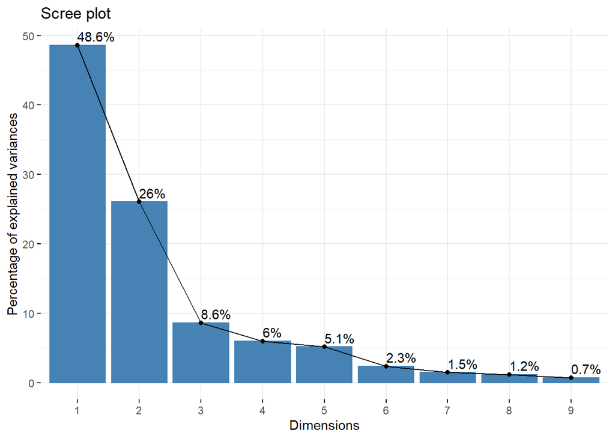

```r
pca %>%
  fviz_eig(addlabels = TRUE)
```

# Analysis of PCA Results

## Analysis Through Biplots

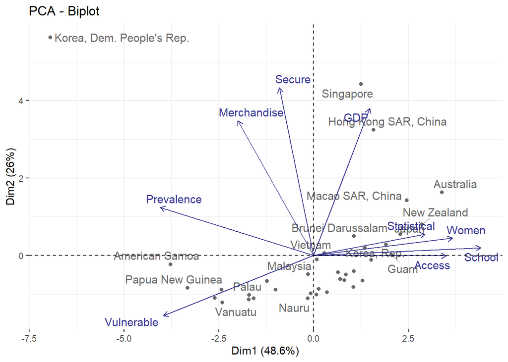

```r
fviz_pca_biplot(pca, axes = c(1, 2), repel = TRUE,
                col.var = "#373792",
                col.ind = "#696969"
                )
```

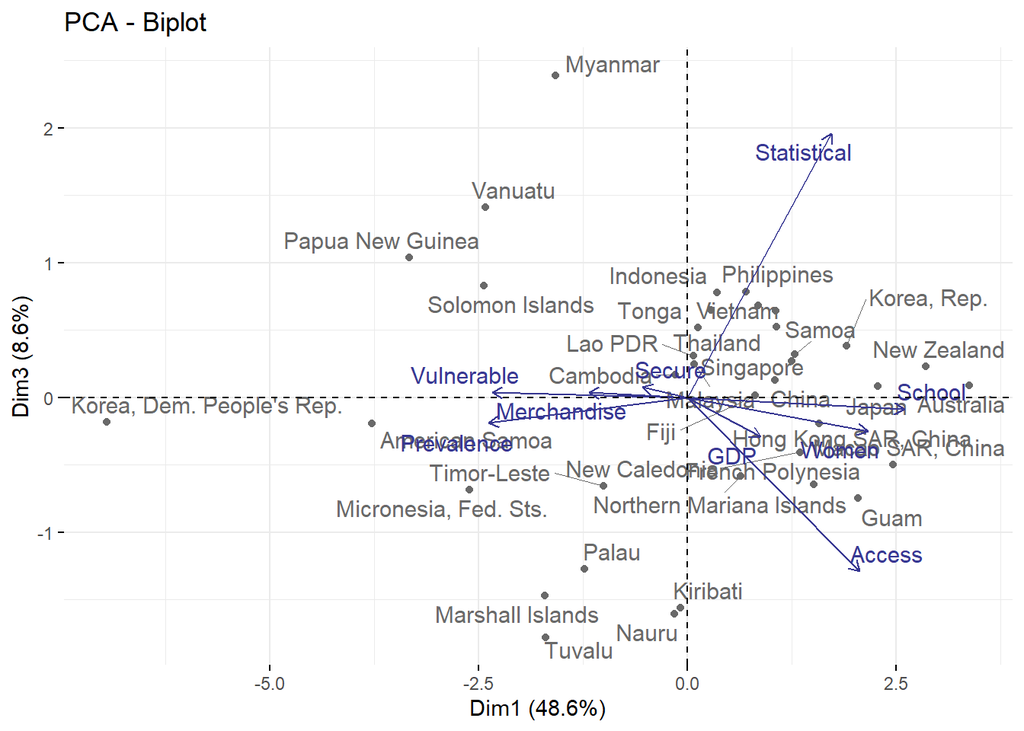

```r
fviz_pca_biplot(pca, axes = c(1, 3), repel = TRUE,
                col.var = "#373792",
                col.ind = "#696969"
                )
```

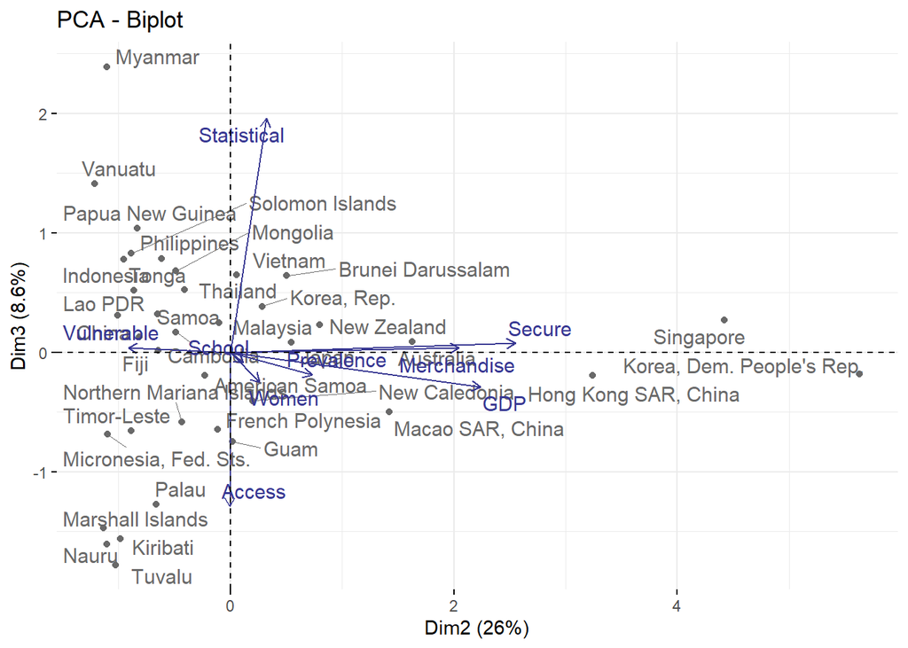

```r
fviz_pca_biplot(pca, axes = c(2, 3), repel = TRUE,
                col.var = "#373792",
                col.ind = "#696969"
                )
```

Looking at the three biplots, we immediately notice that each axis (principal component) has at least one WDI strongly correlated to it (either positively or negatively). At first glance, we see that the variables Statistical, Women, Access, and School are positively correlated with the first principal component while Prevalence and Vulnerable are negatively correlated with it. Meanwhile, the variables Secure, Merchandise, and GDP are positively correlated with the second principal component. Finally, the Statistical variable is positively correlated to the third principal component. Interestingly, we see that when plotting the second and third axes, we notice that Access is negatively correlated with the third principal component.

A closer look at the countries in the biplot shows that the observations are in line with our expectations. For example, Singapore and Hong Kong are close to the GDP vector since they have a consistent record of having a high level of economic development. Meanwhile, countries like Australia and New Zealand are near the School vector since they are known for having one of the best educational systems in the world. Unfortunately, the biplots also reveal that no country has a strong data infrastructure and framework present for the appropriate use of data (Statistical variable) since no country is located near the Statistical vector.

## Analysis Through Graph of Variable

```r
var = get_pca_var(pca)
var
```

```
## Principal Component Analysis Results for variables
##  ===================================================
##   Name       Description
## 1 "$coord"   "Coordinates for the variables"
## 2 "$cor"     "Correlations between variables and dimensions"
## 3 "$cos2"    "Cos2 for the variables"
## 4 "$contrib" "contributions of the variables"
```

### Correlation Circle

In a correlation plot, the positively correlated indicators are grouped together while negatively correlated indicators can be found in opposite (non-adjacent) quadrants. In determining what each principal component describes, the indicators which are closest to the particular axis are to be analyzed (PCA - Principal Component Analysis Essentials, 2017).

```r
var$coord
```

```
##                  Dim.1        Dim.2       Dim.3       Dim.4       Dim.5
## Access       0.7598021 -0.002594916 -0.47531194  0.33168288 -0.16839193
## GDP          0.3222486  0.824257786 -0.10781192 -0.40657418  0.02064724
## Merchandise -0.4329827  0.754204743  0.01317128  0.41616364 -0.10993120
## Prevalence  -0.8776172  0.269341665 -0.07016079 -0.04462890  0.22250336
## School       0.9579594  0.043205494 -0.03150171  0.01113995  0.04675953
## Secure      -0.1958885  0.939811450  0.02754231  0.07645024  0.03328496
## Statistical  0.6377475  0.118669666  0.72215586  0.15526916 -0.01737997
## Vulnerable  -0.8594270 -0.336637716  0.01427266  0.20470146  0.23694030
## Women        0.7966041  0.096665945 -0.09126283  0.12708537  0.55913447
##                   Dim.6       Dim.7        Dim.8        Dim.9
## Access       0.21988887 -0.09703829  0.017019070  0.018602217
## GDP          0.03047899 -0.17570648  0.009500368 -0.086664108
## Merchandise -0.20451796 -0.04653833 -0.110342141 -0.045627835
## Prevalence   0.24882137  0.03331787 -0.190112289  0.040698078
## School       0.04066276  0.21641814 -0.086554828 -0.145472339
## Secure       0.08900247  0.16357862  0.183737974  0.047243690
## Statistical  0.15910254 -0.08746442 -0.016585508  0.006101608
## Vulnerable   0.09024320 -0.06704066  0.120768250 -0.150299316
## Women       -0.11612441 -0.04729055  0.003342176  0.056870365
```

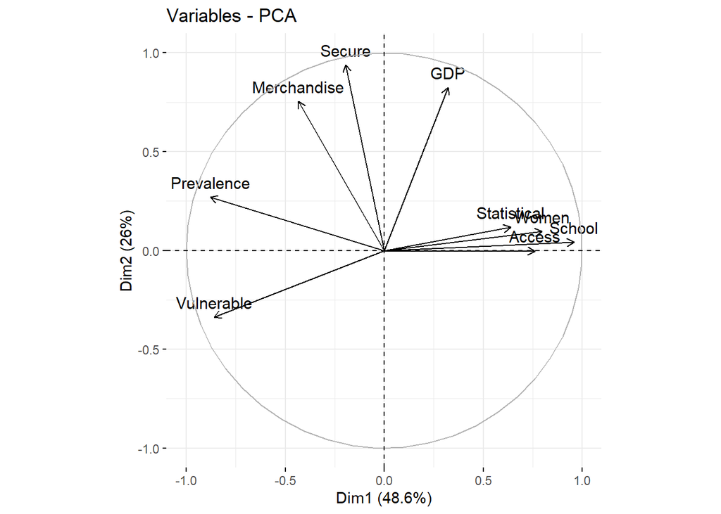

```r
fviz_pca_var(pca, axes = c(1,2))
```

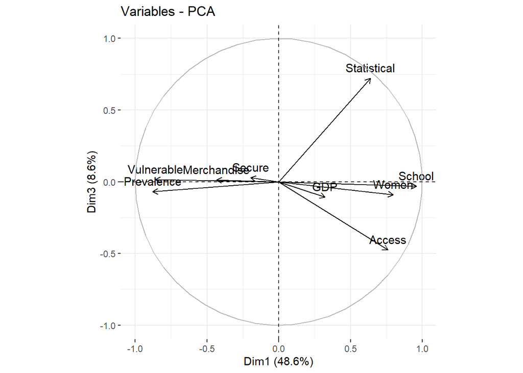

```r
fviz_pca_var(pca, axes = c(1,3))
```

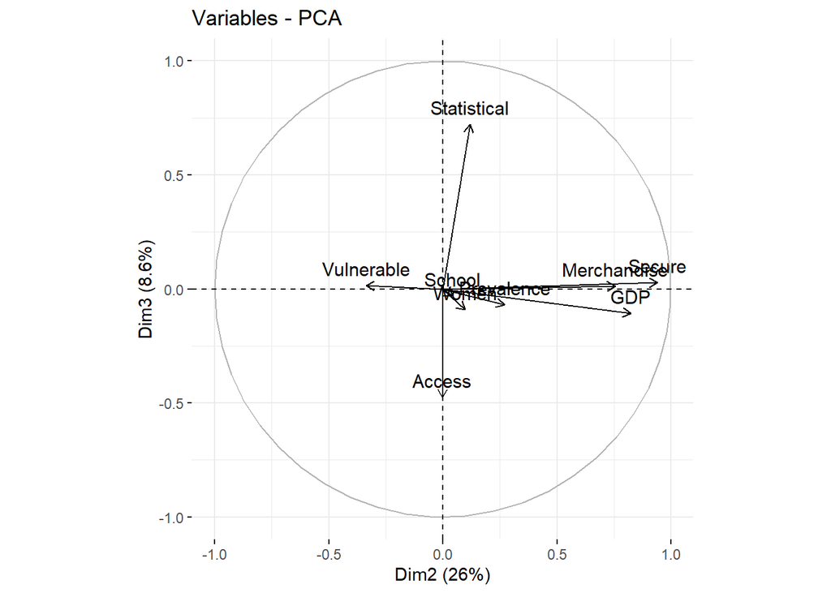

```r
fviz_pca_var(pca, axes = c(2,3))
```

From the results, we see that for the first principal component, the variables Access, Women, Statistical, School are on the positive end and almost completely composed of this PC in the graph. On the other hand, we have the Prevalence and Vulnerable variables on the negative end. Noticeably, these are the variables that are concerned with the welfare of the population. On the positive end, we see the indicators of good welfare whilst on the negative end, we see indicators of bad welfare. From this, we can say that the first PC can be interpreted as the Overall Welfare of the Society. For a country with a positive coordinate on the PC 1 axis, we can say that their citizens have good welfare and are able to enjoy good lives. On the other hand, those countries with negative PC1 coordinate mostly likely have citizens that experience a poor quality of life.

For the second principal component, we see that the variables GDP, Secure, and Merchandise are positively correlated with this axis. These variables are those concerning the economy of a country. Secure Internet servers indicate strong infrastructure and thus, are able to benefit from more investments. GDP per capita shows both the economic production of a country as well as the quality of life. Having high merchandise trade indicates a high degree of international trade of the country which is beneficial for its economy. Thus, we can infer that PC2 refers to the Economic Strength of a Country. Those countries found on the positive side should be developed countries that have better and larger economies. On the other hand, those with negative PC2 coordinates are most likely developing countries with weaker economies.

For the third principal component, we see that it is primarily composed of the Statistical variable. This suggests that the third principal component represents the Data Maturity of the Country. This indicates how high quality data is used in guiding decision making. Those countries found on the positive side should be countries with strong national statistical systems. On the other hand, those with negative coordinates are likely to have challenges with their statistical systems.

### Quality of Representation

```r
var$cos2
```

```
##                  Dim.1         Dim.2        Dim.3        Dim.4        Dim.5
## Access      0.57729922 0.00000673359 0.2259214411 0.1100135307 0.0283558430
## GDP         0.10384416 0.67940089705 0.0116234093 0.1653025633 0.0004263085
## Merchandise 0.18747398 0.56882479390 0.0001734826 0.1731921770 0.0120848698
## Prevalence  0.77021188 0.07254493239 0.0049225359 0.0019917384 0.0495077436
## School      0.91768616 0.00186671467 0.0009923580 0.0001240984 0.0021864539
## Secure      0.03837232 0.88324556106 0.0007585787 0.0058446388 0.0011078887
## Statistical 0.40672190 0.01408248970 0.5215090856 0.0241085111 0.0003020634
## Vulnerable  0.73861480 0.11332495171 0.0002037089 0.0419026863 0.0561407080
## Women       0.63457806 0.00934430491 0.0083289038 0.0161506909 0.3126313591
##                    Dim.6       Dim.7         Dim.8         Dim.9
## Access      0.0483511149 0.009416430 0.00028964873 0.00034604248
## GDP         0.0009289688 0.030872765 0.00009025699 0.00751066760
## Merchandise 0.0418275959 0.002165817 0.01217538813 0.00208189936
## Prevalence  0.0619120725 0.001110080 0.03614268244 0.00165633358
## School      0.0016534603 0.046836811 0.00749173830 0.02116220144
## Secure      0.0079214402 0.026757964 0.03375964300 0.00223196625
## Statistical 0.0253136176 0.007650025 0.00027507908 0.00003722962
## Vulnerable  0.0081438351 0.004494450 0.01458497024 0.02258988449
## Women       0.0134848781 0.002236396 0.00001117014 0.00323423840
```

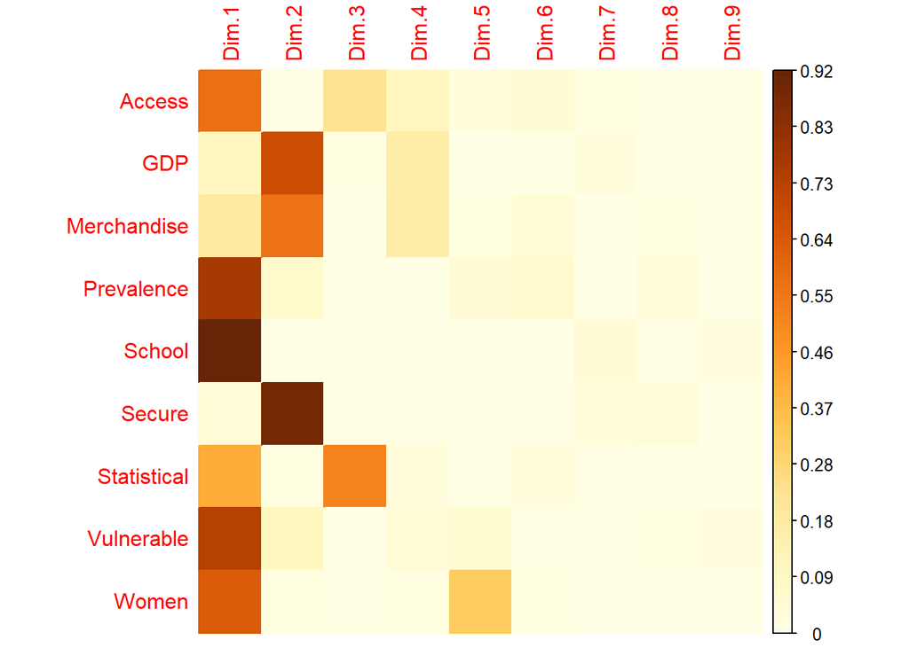

```r
corrplot(var$cos2, method = "color", is.corr = FALSE)
```

The correlation plot supports our initial hypothesis about the three principal components

- The Access, Prevalence, School, Vulnerable, Women variables are strongly represented in the first principal component supporting the hypothesis that the first principal component represents the overall welfare of the population.
- The GDP, Merchandise, and Secure variables are strongly represented in the second principal component. We note that these variables are generally predictors of the economic strength of a country. Thus, the second principal component can be an indicator of the economic progress of a country.
- For the third principal component, we note that only the Statistical variable is strongly represented with it. This indicates that the third principal component can be interpreted as the data maturity of a country.

### Contribution of Variables to PCs

```r
var$contrib
```

```
##                  Dim.1         Dim.2       Dim.3       Dim.4       Dim.5
## Access      13.1960064  0.0002874358 29.17247769 20.42467018  6.12777037
## GDP          2.3736880 29.0014896495  1.50089185 30.68940988  0.09212635
## Merchandise  4.2853129 24.2813432309  0.02240122 32.15416388  2.61157133
## Prevalence  17.6056378  3.0967152309  0.63563055  0.36977815 10.69875031
## School      20.9766308  0.0796841841  0.12813986  0.02303961  0.47249828
## Secure       0.8771212 37.7029778860  0.09795272  1.08509215  0.23941759
## Statistical  9.2969203  0.6011372386 67.34071847  4.47588932  0.06527667
## Vulnerable  16.8833863  4.8374861269  0.02630425  7.77948442 12.13215091
## Women       14.5052962  0.3988790174  1.07548340  2.99847240 67.56043817
##                  Dim.6      Dim.7       Dim.8       Dim.9
## Access      23.0752176  7.1585654  0.27632812  0.56867682
## GDP          0.4433436 23.4701171  0.08610618 12.34282733
## Merchandise 19.9619156  1.6464987 11.61545612  3.42133691
## Prevalence  29.5470859  0.8439061 34.48052230  2.72197366
## School       0.7891019 35.6063159  7.14720192 34.77738758
## Secure       3.7804497 20.3419599 32.20707608  3.66795277
## Statistical 12.0807397  5.8157076  0.26242851  0.06118215
## Vulnerable   3.8865860  3.4167744 13.91422434 37.12360315
## Women        6.4355599  1.7001548  0.01065644  5.31505963
```

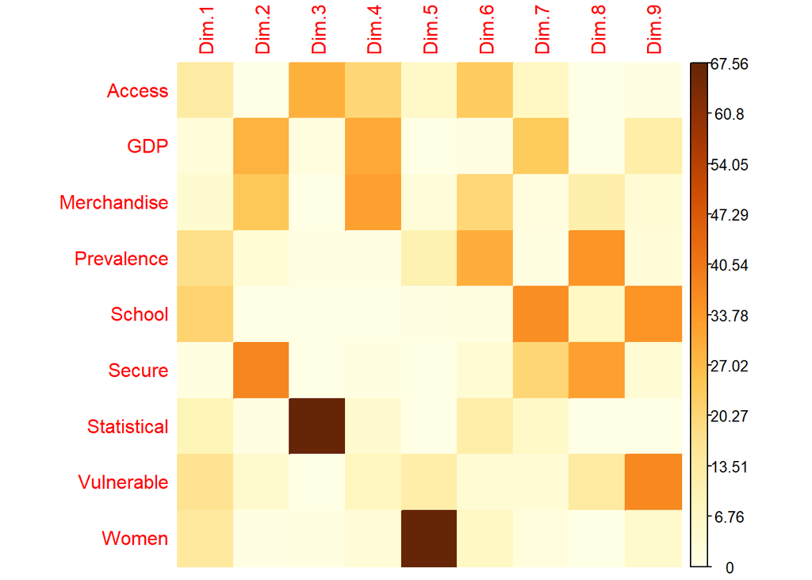

```r
corrplot(var$contrib, method = "color", is.corr = FALSE)
```

Looking at the contribution of each variable, we get the following insights

## Analysis through Graph of Observations

```r
ind = get_pca_ind(pca)
ind
```

```
## Principal Component Analysis Results for individuals
##  ===================================================
##   Name       Description
## 1 "$coord"   "Coordinates for the individuals"
## 2 "$cos2"    "Cos2 for the individuals"
## 3 "$contrib" "contributions of the individuals"
```

### Coordinate for the Individuals

```r
ind$coord
```

```
##                                 Dim.1       Dim.2       Dim.3       Dim.4
## American Samoa            -3.77303148 -0.22706214 -0.19232575 -0.13098169
## Australia                  3.38230958  1.63049309  0.09053613 -0.86097503
## Brunei Darussalam          1.06341327  0.50072808  0.64084330 -0.45254938
## Cambodia                  -0.14684044 -0.48766906  0.17006563  0.75620547
## China                      1.05592054 -0.81682706  0.13076503  0.23703682
## Fiji                       0.81220988 -0.64294890  0.01402836  0.58882221
## French Polynesia           1.51749697 -0.11606792 -0.64700473 -0.35656901
## Guam                       2.04815199  0.01935031 -0.75019544 -0.96377096
## Hong Kong SAR, China       1.58329535  3.24013524 -0.19606961  1.15082142
## Indonesia                  0.35503672 -0.95546102  0.77897762  0.32177482
## Japan                      2.28817136  0.54651183  0.08332538 -0.67645659
## Kiribati                  -0.07668212 -0.98163640 -1.56363042  0.38196372
## Korea, Dem. People's Rep. -6.94892081  5.63180001 -0.18357940  0.19239880
## Korea, Rep.                1.90642124  0.28827525  0.38497800 -0.13322398
## Lao PDR                    0.07241391 -1.00660426  0.30679942  1.18980834
## Macao SAR, China           2.46308126  1.42145332 -0.49936140 -1.99469404
## Malaysia                   0.08560044 -0.10317493  0.24894183  0.26503332
## Marshall Islands          -1.70559163 -1.13494070 -1.47340489  0.03845506
## Micronesia, Fed. Sts.     -2.60671388 -1.10005560 -0.68458702 -0.44876288
## Mongolia                   0.84958839 -0.49081508  0.68058446  0.99700833
## Myanmar                   -1.57535130 -1.10694657  2.39174175 -0.71956880
## Nauru                     -0.15082512 -1.10489424 -1.60915621 -0.12098939
## New Caledonia              1.35167088  0.19889506 -0.40635214 -0.25466816
## New Zealand                2.86362566  0.79982997  0.22961978 -0.42258491
## Northern Mariana Islands   0.64032304 -0.43547582 -0.58247955 -0.09853772
## Palau                     -1.23309230 -0.66225984 -1.27261884 -0.17286271
## Papua New Guinea          -3.32352922 -0.83136208  1.04054677 -0.83325305
## Philippines                0.70578398 -0.61334506  0.78680526  0.32282871
## Samoa                      1.29286801 -0.65263633  0.31956426  0.43216861
## Singapore                  1.25492086  4.41915446  0.26974716  0.20560236
## Solomon Islands           -2.43089386 -0.88763486  0.82889809 -0.64207356
## Thailand                   1.06676319 -0.41043822  0.52471823  0.89372249
## Timor-Leste               -1.00172841 -0.88496494 -0.65939460  0.24529333
## Tonga                      0.13225932 -0.86375149  0.51659043  0.28570480
## Tuvalu                    -1.69518769 -1.02425687 -1.77973004  0.13437491
## Vanuatu                   -2.41105931 -1.21273745  1.41077830 -1.13221938
## Vietnam                    0.28812175  0.05734019  0.65103486  1.77571771
##                                  Dim.5       Dim.6        Dim.7        Dim.8
## American Samoa            -0.063394620 -0.28297587 -0.451446090 -0.415369890
```

[output cut: 59 more lines]

```
## New Caledonia              0.314742954
## New Zealand               -0.078585514
## Northern Mariana Islands  -0.027635723
## Palau                     -0.188616801
## Papua New Guinea           0.287031809
## Philippines                0.522183626
## Samoa                      0.292053086
## Singapore                  0.314524436
## Solomon Islands            0.162191369
## Thailand                  -0.567534649
## Timor-Leste                0.110280427
## Tonga                     -0.296590532
## Tuvalu                     0.045423075
## Vanuatu                   -0.129583581
## Vietnam                   -0.263133550
```

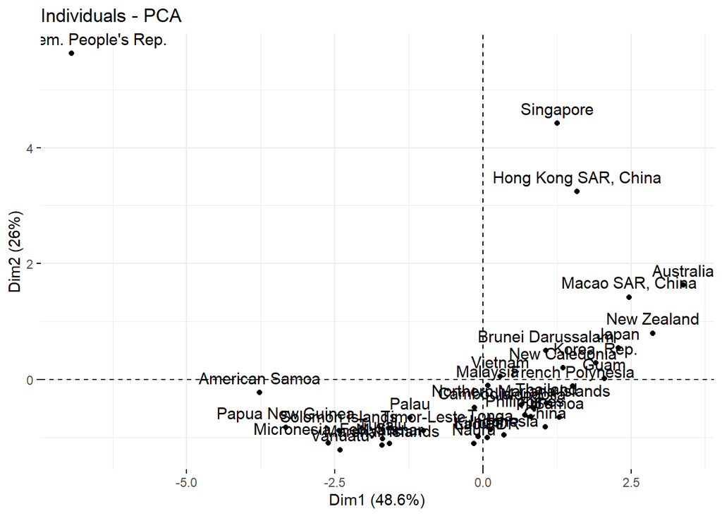

```r
fviz_pca_ind(pca, axes = c(1,2))
```

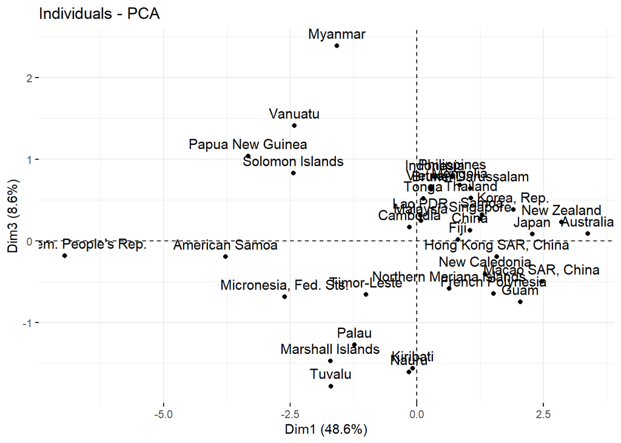

```r
fviz_pca_ind(pca, axes = c(1,3))
```

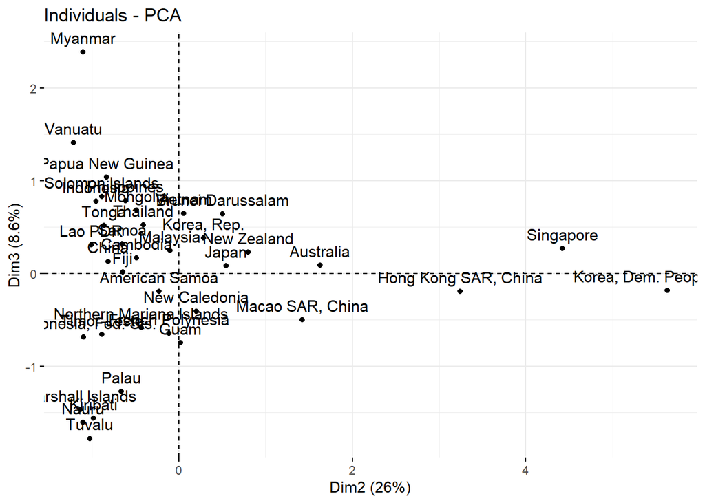

```r
fviz_pca_ind(pca, axes = c(2,3))
```

From the plot of the first and second principal components, we immediately notice a linear pattern among the observations. This indicates that there is a linear relationship between the welfare of the citizens and the economic strength of the country. Countries such as Australia, New Zealand with higher overall citizens welfare also have a strong economic strength while countries like Papua New Guinea with low economic growth also have poor overall welfare for citizens. Thus, we can say that in some sense, the economic growth really translated into the improvement of the welfare of the citizens in the area. This increase in welfare could come through economic growth leading to improved healthcare systems, increased food intake, as well as better access to the other basic needs for even the poorest of the poor. Contrary to Clarke (2003), who concluded that in economies that grew rapidly, welfare did not improve, we found that even in these times of rapid economic growth, there was trend within the Asia Pacific countries that increasing economic strength really translated to increased welfare.

From the second plot of the first and third principal components, we do not see any noticeable pattern. Unlike the first plot, there seems to be no relationship between the data maturity of the country and the overall welfare of the citizens. Countries like Japan and Guam having positive overall welfare are located in different quadrants with respect to the first and third principal components. Thus, there seems to be no evidence that the high overall welfare of the population can be attributed to politicians using data efficiently in decisions and policy making.

Similarly, in the third plot of the second and third principal components, we also do not see any noticeable pattern. There appears to be no relationship between the two principal components. Countries like Myanmar and Tuvalu with low economic strength are located in different quadrants with respect to the second and third principal components. Thus, there is no evidence that a higher economic strength can be attributed to officials efficiently using data for policies.

### Squared Cosine of a Component with an Observation (cos2)

The squared cosine shows the importance of a principal component for a given observation (country). It measures the square of the cosine of the angle from the right triangle made with the origin, the observation, and its projection on the principal component. Thus, a higher value indicates that the principal component is more important in getting the full information about the country (PCA - Principal Component Analysis Essentials, 2017).

```r
ind$cos2
```

```
##                                  Dim.1         Dim.2        Dim.3        Dim.4
## American Samoa            0.9555404898 0.00346065000 0.0024828079 0.0011515675
## Australia                 0.6996705921 0.16259411995 0.0005013151 0.0453365036
## Brunei Darussalam         0.1779776473 0.03946073807 0.0646345912 0.0322324461
## Cambodia                  0.0174366785 0.19231927086 0.0233886695 0.4624364123
## China                     0.5440239900 0.32554858128 0.0083433176 0.0274149336
## Fiji                      0.4539851243 0.28448410215 0.0001354312 0.2386016518
## French Polynesia          0.6968001846 0.00407640194 0.1266681707 0.0384715593
## Guam                      0.7204339897 0.00006430517 0.0966537419 0.1595208662
## Hong Kong SAR, China      0.1532251888 0.64170078127 0.0023497782 0.0809509904
## Indonesia                 0.0471567886 0.34152588420 0.2270113838 0.0387348423
## Japan                     0.8616563060 0.04915368874 0.0011426456 0.0753072607
## Kiribati                  0.0013263874 0.21736193297 0.5515061973 0.0329098883
## Korea, Dem. People's Rep. 0.6022414352 0.39557638402 0.0004203236 0.0004616795
## Korea, Rep.               0.8476981577 0.01938287640 0.0345680860 0.0041396946
## Lao PDR                   0.0009749842 0.18839577027 0.0175009931 0.2632131806
## Macao SAR, China          0.4356743387 0.14510076576 0.0179074784 0.2857308165
## Malaysia                  0.0016574624 0.00240790903 0.0140180459 0.0158888578
## Marshall Islands          0.4258415403 0.18855769158 0.3177913901 0.0002164736
## Micronesia, Fed. Sts.     0.7567165616 0.13476458546 0.0521919867 0.0224274738
## Mongolia                  0.2763101217 0.09221794992 0.1773142811 0.3805197784
## Myanmar                   0.2393148071 0.11815934043 0.5516241978 0.0499297489
## Nauru                     0.0053914218 0.28933258751 0.6136946592 0.0034693693
## New Caledonia             0.7480722924 0.01619756219 0.0676093488 0.0265552838
## New Zealand               0.8513082150 0.06641247805 0.0054735985 0.0185388291
## Northern Mariana Islands  0.4282133374 0.19805691819 0.3543425467 0.0101406765
## Palau                     0.3634006498 0.10482174103 0.3870715269 0.0071416272
## Papua New Guinea          0.7624267586 0.04770671941 0.0747347069 0.0479239879
## Philippines               0.2310924663 0.17452270346 0.2871948825 0.0483488899
## Samoa                     0.6571208117 0.16744775699 0.0401470130 0.0734248867
## Singapore                 0.0697510682 0.86496104314 0.0032227896 0.0018722954
## Solomon Islands           0.7489371005 0.09985781215 0.0870794397 0.0522495937
## Thailand                  0.3471164567 0.05138480903 0.0839830160 0.2436377279
## Timor-Leste               0.1660255070 0.12957671287 0.0719392000 0.0099551153
## Tonga                     0.0069552158 0.29664405370 0.1061086394 0.0324558580
## Tuvalu                    0.3978817105 0.14525669628 0.4385576178 0.0025000850
## Vanuatu                   0.4960352560 0.12549613048 0.1698299570 0.1093850380
## Vietnam                   0.0200851046 0.00079550026 0.1025487837 0.7629039634
##                                    Dim.5         Dim.6          Dim.7
## American Samoa            0.000269757199 0.00537485881 0.013679808856
```

[output cut: 59 more lines]

```
## New Caledonia             0.086174546042 0.04056147009
## New Zealand               0.000004055138 0.00064112001
## Northern Mariana Islands  0.005346679654 0.00079763385
## Palau                     0.004125417027 0.00850266914
## Papua New Guinea          0.015286152764 0.00568668514
## Philippines               0.047584287840 0.12649946606
## Samoa                     0.005203957348 0.03353207611
## Singapore                 0.023717393822 0.00438154190
## Solomon Islands           0.003819580417 0.00333402483
## Thailand                  0.049088686436 0.09824804696
## Timor-Leste               0.055376111767 0.00201220262
## Tonga                     0.000059632347 0.03497619770
## Tuvalu                    0.006274103335 0.00028567449
## Vanuatu                   0.020244668200 0.00143283675
## Vietnam                   0.035835063453 0.01675230107
```

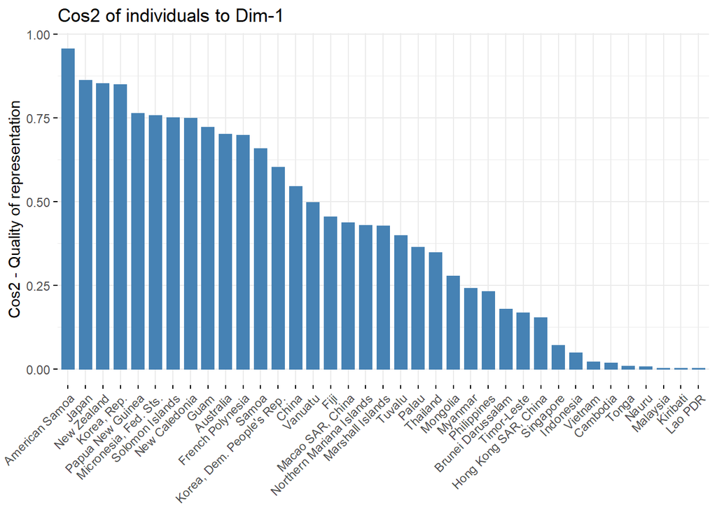

```r
fviz_cos2(pca, choice = "ind", axes = 1)
```

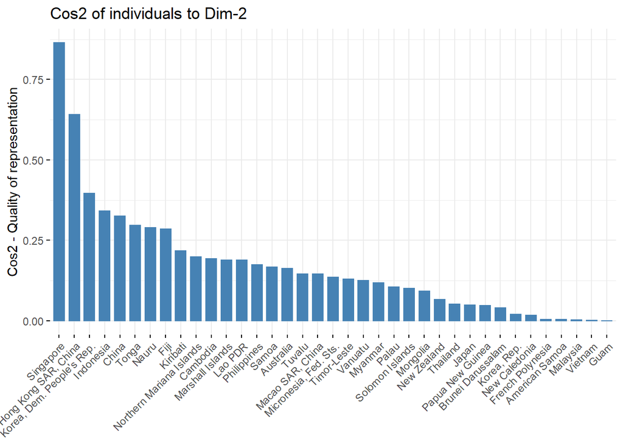

```r
fviz_cos2(pca, choice = "ind", axes = 2)
```

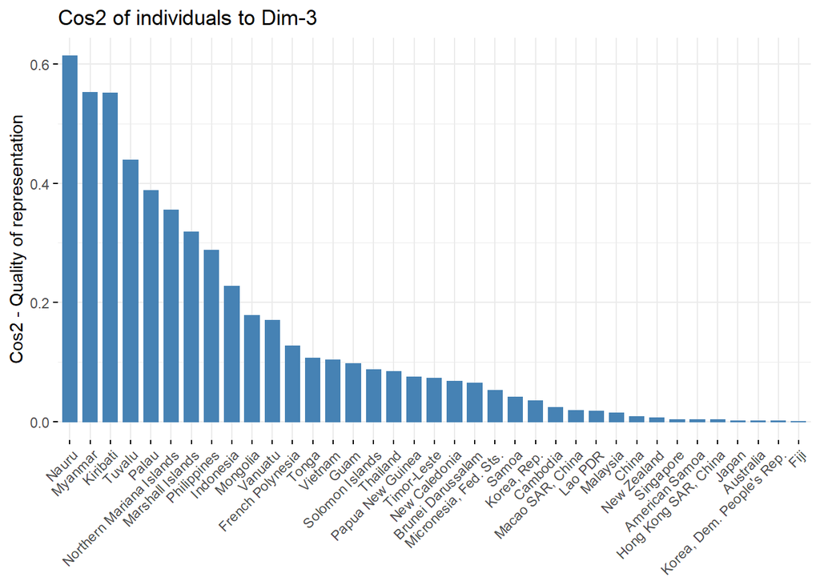

```r
fviz_cos2(pca, choice = "ind", axes = 3)
```

For the first principal component (representing welfare), we see that for countries like American Samoa, Japan, and New Zealand, this principal component gives us a good picture of the full information about the country. Noticeably, the first principal component of North Korea has the most negative PC1 coordinate, which is as expected as it has been noted that North Korea citizens have one of the worst qualities of life in the world. This also means that they are closer to the first principal component in the biplots either in the positive direction or the negative direction. Therefore, these are the countries with either very good or very bad overall welfare. Meanwhile, for countries like Malaysia, Kiribati, Lao PDR, the first principal component is not that useful in reconstructing the entire information about the country. This means that they are not located near the first principal component and have average overall welfare.

For the second principal component (representing economic growth), countries like Singapore and Hong Kong have higher values indicating that this principal component is useful in giving us a good picture of the entire information about the country. This also means that these countries either have a very high or low economic strength as they are located near the second principal component. This stems from the fact that Singapore and Hongkong are considered economic centers in the region. Moreover, for countries like Vietnam and Guam, this principal component is not as strong since they only have average economic strength and are not located near this principal component.

For the third principal component representing data maturity, countries like Nauru, Myanmar, and Kiribati have a high squared cosine either because they have a high data maturity or low data maturity. On the other hand, Australia, Korea, and Fiji have the lowest value. Furthermore, we also see that the third principal component is not very useful in getting more information about a lot of countries.

### Contribution of an Observation to a Component

```r
ind$contrib
```

```
##                                  Dim.1         Dim.2         Dim.3        Dim.4
## American Samoa             8.794692968  0.0594814992  0.1290889351  0.086085180
## Australia                  7.067511733  3.0671173535  0.0286060580  3.719532355
## Brunei Darussalam          0.698624759  0.2892653106  1.4332364152  1.027635682
## Cambodia                   0.013320827  0.2743739507  0.1009362736  2.869371998
## China                      0.688814539  0.7697553231  0.0596756757  0.281928416
## Fiji                       0.407545745  0.4769198313  0.0006867959  1.739704895
## French Polynesia           1.422641561  0.0155423568  1.4609287981  0.637961431
## Guam                       2.591577441  0.0004319848  1.9640972388  4.660740199
## Hong Kong SAR, China       1.548687158 12.1120802566  0.1341636077  6.645430162
## Indonesia                  0.077872904  1.0532183367  2.1176983589  0.519530847
## Japan                      3.234572698  0.3445812170  0.0242308547  2.296080423
## Kiribati                   0.003632688  1.1117158003  8.5326192061  0.732068060
## Korea, Dem. People's Rep. 29.831462890 36.5920646576  0.1176148122  0.185742782
## Korea, Rep.                2.245316468  0.0958753999  0.5172326995  0.089057812
## Lao PDR                    0.003239543  1.1689878506  0.3284908066  7.103317750
## Macao SAR, China           3.747980355  2.3310826361  0.8702500900 19.964562927
## Malaysia                   0.004526805  0.0122812002  0.2162767783  0.352458652
## Marshall Islands           1.797173210  1.4860684175  7.5763207959  0.007420175
## Micronesia, Fed. Sts.      4.197846524  1.3961167475  1.6355787634  1.010511070
## Mongolia                   0.445920009  0.2779254191  1.6165092658  4.987751419
## Myanmar                    1.533185342  1.4136626571 19.9637771583  2.598076108
## Nauru                      0.014053588  1.4084255237  9.0367143904  0.073451695
## New Caledonia              1.128708360  0.0456394570  0.5762610178  0.325429200
## New Zealand                5.066083172  0.7380534527  0.1840063228  0.896056080
## Northern Mariana Islands   0.253301689  0.2187865160  1.1840649196  0.048720554
## Palau                      0.939357689  0.5059985862  5.6521130157  0.149937363
## Papua New Guinea           6.823997013  0.7973938661  3.7786559443  3.483862826
## Philippines                0.307739625  0.4340124672  2.1604720239  0.522939612
## Samoa                      1.032638238  0.4913997770  0.3563941246  0.937159831
## Singapore                  0.972909636 22.5304999882  0.2539381307  0.212111108
## Solomon Islands            3.650663635  0.9089943024  2.3978191106  2.068601292
## Thailand                   0.703033252  0.1943515683  0.9608740091  4.007860557
## Timor-Leste                0.619925942  0.9035341948  1.5174168955  0.301910829
## Tonga                      0.010806683  0.8607362314  0.9313370062  0.409583347
## Tuvalu                     1.775314937  1.2103479333 11.0540749917  0.090603215
## Vanuatu                    3.591332490  1.6967819831  6.9459505225  6.432331090
## Vietnam                    0.051285182  0.0037932439  1.4791854842 15.821770354
##                                   Dim.5        Dim.6         Dim.7
## American Samoa             0.0234726975  1.032847996  4.1874515105
```

[output cut: 59 more lines]

```
## New Caledonia              5.4266158662  4.399936619
## New Zealand                0.0010071706  0.274295942
## Northern Mariana Islands   0.1320000098  0.033921577
## Palau                      0.4450666526  1.580138431
## Papua New Guinea           5.7101931269  3.659269890
## Philippines                2.6446798784 12.111024620
## Samoa                      0.3413096857  3.788418819
## Singapore                 13.8070376993  4.393829216
## Solomon Islands            0.7770590744  1.168395472
## Thailand                   4.1494828842 14.306030613
## Timor-Leste                8.6297727061  0.540171002
## Tonga                      0.0038670128  3.907049861
## Tuvalu                     1.1683823878  0.091640502
## Vanuatu                    6.1173824976  0.745820543
## Vietnam                    3.8188964939  3.075295387
```

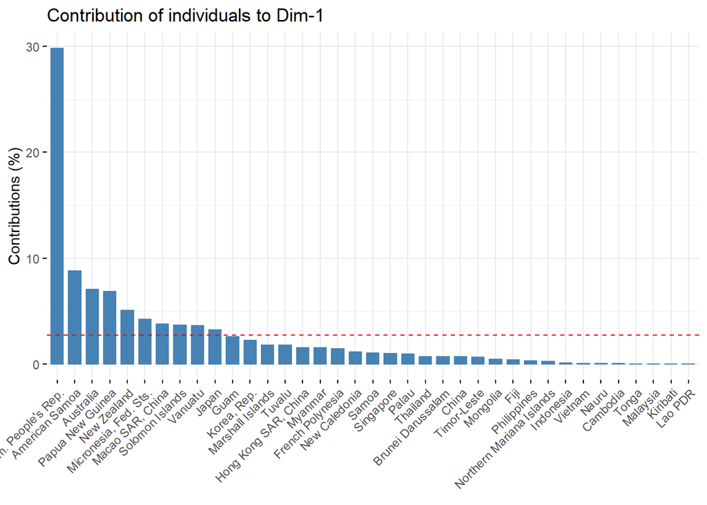

```r
fviz_contrib(pca, choice = "ind", axes = 1)
```

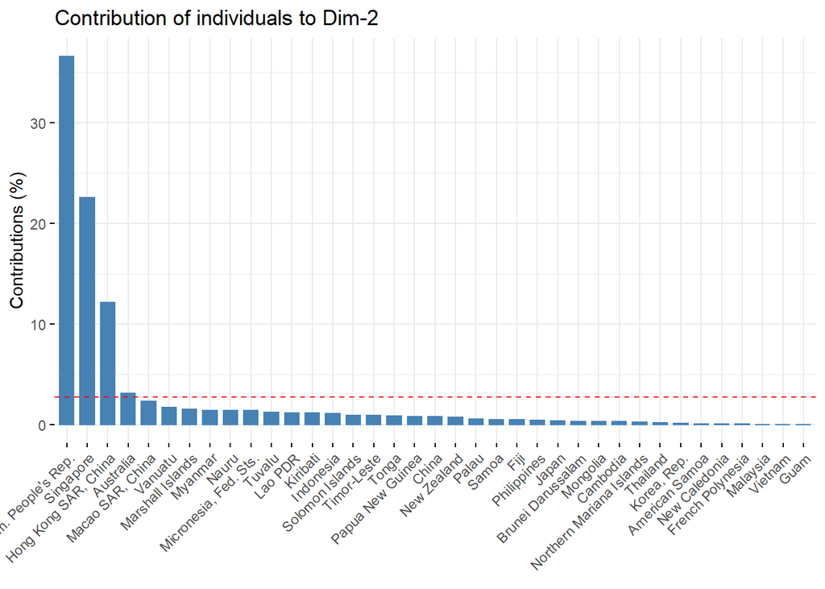

```r
fviz_contrib(pca, choice = "ind", axes = 2)
```

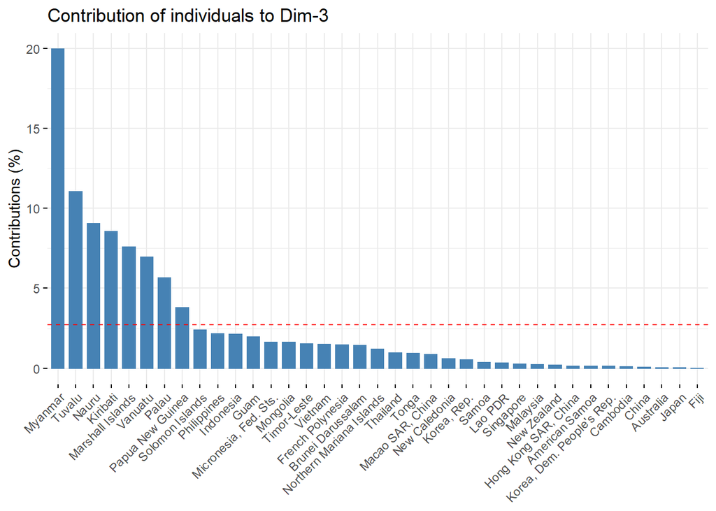

```r
fviz_contrib(pca, choice = "ind", axes = 3)
```

As seen in the first graph, North Korea contributes the most to the first principal component. This is consistent with our earlier biplot since North Korea has the most negative coordinate in the first principal component. American Samoa and Australia also followed by having a large contribution to the first component. Meanwhile, countries like Malaysia, Kiribati, and Lao PDR have the least contribution to the first principal component. We also note that the average contribution per county is 2.70%.

In the second graph, we also see that Korea has the most contribution since it has the most positive coordinate in the second principal component. This is followed by Singapore and Hong Kong. On the other end, Malaysia, Vietnam, and Guam has the least contribution. Similarly, the average contribution per country is also 2.70%.

In the third graph, we can see that Myanmar, Tuvalu, Nauru have the highest contribution since they are located in the extremes of the principal component while Australia, Japan, Fiji has the lowest contribution. Similarly, the average contribution per country is also 2.70%.

# Conclusions and Recommendations

As the COVID-19 Pandemic goes on, more and more data about how the impact on the drastic change in the economy changed the welfare of the citizens would be readily available. In this paper, we were limited by the missing data on the year 2020, and as such, were forced to only use 2019 data. For future research, we recommend that researchers try to examine the same effect using data about countries during the year 2020, 2021, and future years that are to be affected by the pandemic. Examining this would be helpful as we can really be able to see if economic growth and rebound is inclusive, and the recovery from the welfare loss because of the pandemic can be accelerated by the growth of the economy. Lastly, this would guide policy makers on whether they have to implement more measures to ensure that economic growth is inclusive and does indeed translate to increased welfare.

# References

A Long-term Perspective on Environment and Development in the Asia-Pacific Region. (n.d.). Retrieved December 16, 2021, from https://www.env.go.jp/en/earth/ecoasia/workshop/bluebook/chapter1-1.html

Clarke, M. (2003). Is economic growth desirable? A welfare economic analysis of the Thai experience [PhD, Victoria University]. https://vuir.vu.edu.au/232/

Imputation of missing values for PCA. (n.d.). Retrieved December 17, 2021, from https://stats.stackexchange.com/questions/35561/imputation-of-missing-values-for-pca

PCA - Principal Component Analysis Essentials. (2017, September 23). http://www.sthda.com/english/articles/31-principal-component-methods-in-r-practical-guide/112-pca-principal-component-analysis-essentials/

Rubin, A., & Segal, D. (2015). The effects of economic growth on income inequality in the US. Journal of Macroeconomics, 45, 258–273. https://doi.org/10.1016/j.jmacro.2015.05.007